# Data Visualisation

Mathias Steilen

2024-03-12

## The Goal

Output: Have a subset of variables that will be selected for modelling.

```r
# Read data
df = read_csv("./data_cleaned_UTC.csv") |>
  arrange(date) |>
  select(-contains("ATC")) |>
  select(-c(auction_price_de_ch, allocatedCapacity_de_ch))
dim(df)
```

```
## [1] 44510    89
```

```r
df
```

```
## # A tibble: 44,510 × 89
##    date                auction_price_ch_de allocatedCapacity_ch_de
##    <dttm>                            <dbl>                   <dbl>
##  1 2018-12-31 23:00:00                   0                    4232
##  2 2019-01-01 00:00:00                   0                    4232
##  3 2019-01-01 01:00:00                   0                    4232
##  4 2019-01-01 02:00:00                   0                    4232
##  5 2019-01-01 03:00:00                   0                    4232
##  6 2019-01-01 04:00:00                   0                    4232
##  7 2019-01-01 05:00:00                   0                    4232
##  8 2019-01-01 06:00:00                   0                    4232
##  9 2019-01-01 07:00:00                   0                    4232
## 10 2019-01-01 08:00:00                   0                    4232
## # ℹ 44,500 more rows
## # ℹ 86 more variables: day_ahead_price_at <dbl>, day_ahead_price_ch <dbl>,
## #   day_ahead_price_de <dbl>, day_ahead_price_fr <dbl>, actual_load_at <dbl>,
## #   actual_load_ch <dbl>, actual_load_de <dbl>, actual_load_fr <dbl>,
## #   actual_load_it <dbl>, solar_forecast_de <dbl>,
## #   wind_onshore_forecast_fr <dbl>, biomass_actual_aggregated_at <dbl>,
## #   fossil_gas_actual_aggregated_at <dbl>, …
```

### The Target Variable

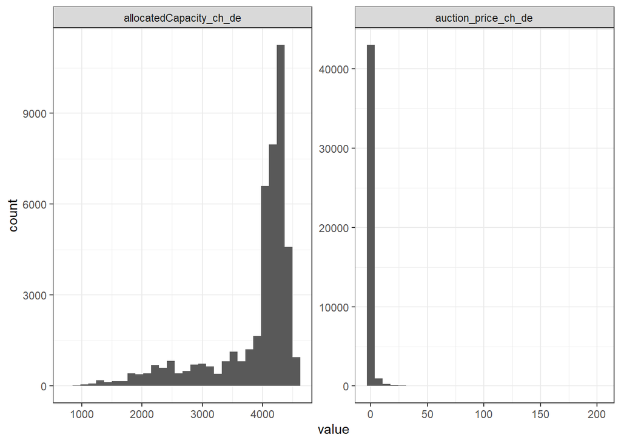

```r
df |>
  select(date, auction_price_ch_de, allocatedCapacity_ch_de) |>
  pivot_longer(-date) |>
  ggplot(aes(value)) +
  geom_histogram() +
  facet_wrap(~ name, scales = "free")
```

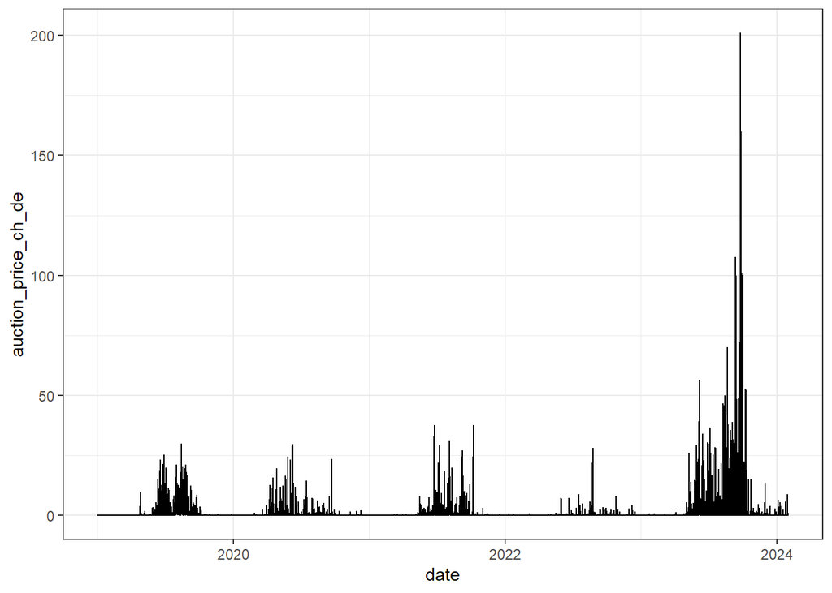

```r
df |>
  select(date, auction_price_ch_de, allocatedCapacity_ch_de) |>
  ggplot(aes(date, auction_price_ch_de)) +
  geom_line()
```

Generally, the higher the spread, the higher the auction price (makes sense), but there are plenty of times still where the JAO price is much too low. This chart does not reveal a structural mispricing of the auction.

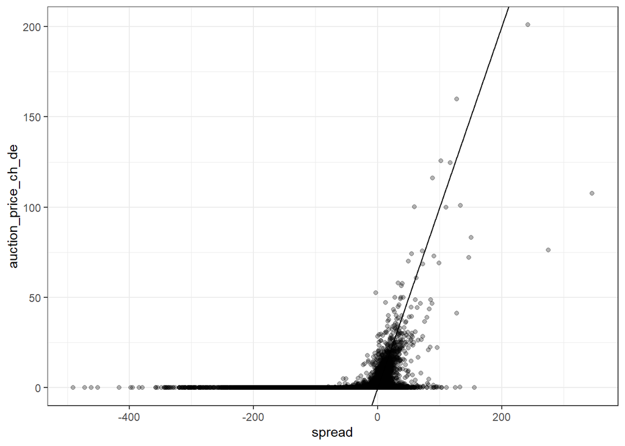

```r
df |>
  transmute(auction_price_ch_de, spread = day_ahead_price_de - day_ahead_price_ch) |>
  ggplot(aes(spread, auction_price_ch_de)) +
  geom_point(alpha = 0.3) +
  geom_abline()
```

### Seasonality of target

Distribution by year, month, week, day of week, hour in day

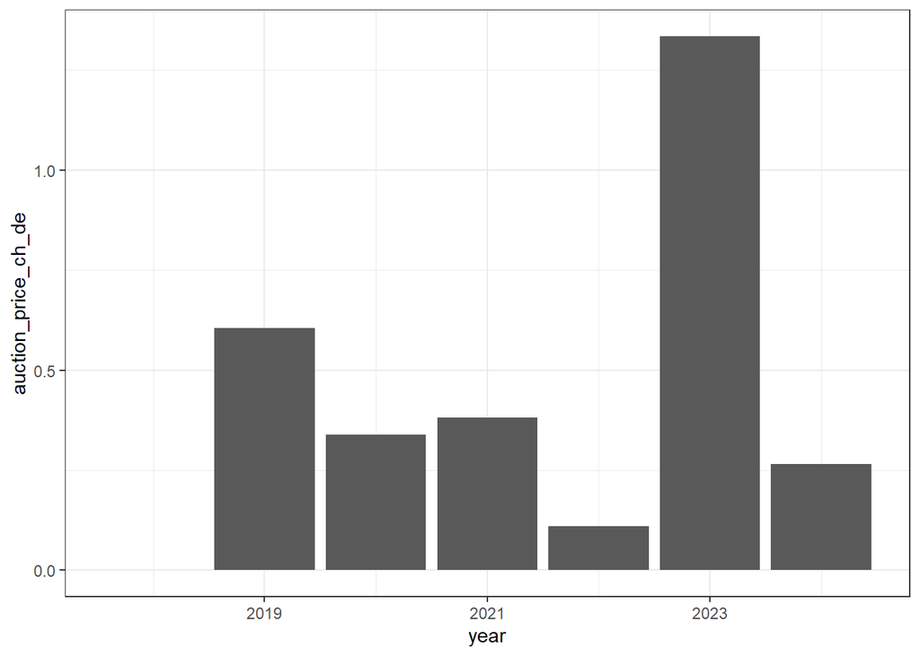

```r
df |>
  mutate(year = year(date))  |>
  group_by(year) |>
  summarise(auction_price_ch_de = mean(auction_price_ch_de)) |>
  ungroup() |>
  ggplot(aes(year, auction_price_ch_de)) +
  geom_col()
```

There does not seem to be a trend in the average auction price.

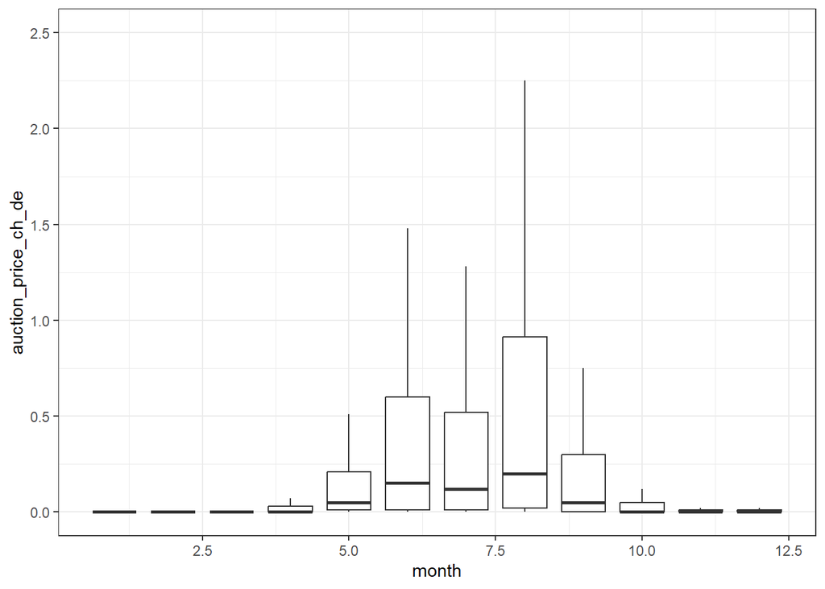

```r
df |>
  mutate(month = month(date)) |>
  ggplot(aes(month, auction_price_ch_de, group = month)) +
  geom_boxplot(outlier.colour = NA) +
  coord_cartesian(ylim = c(0, 2.5))
```

Auction prices are higher in the summer months, this ties in well with the spread being positive much more often over the summer months:

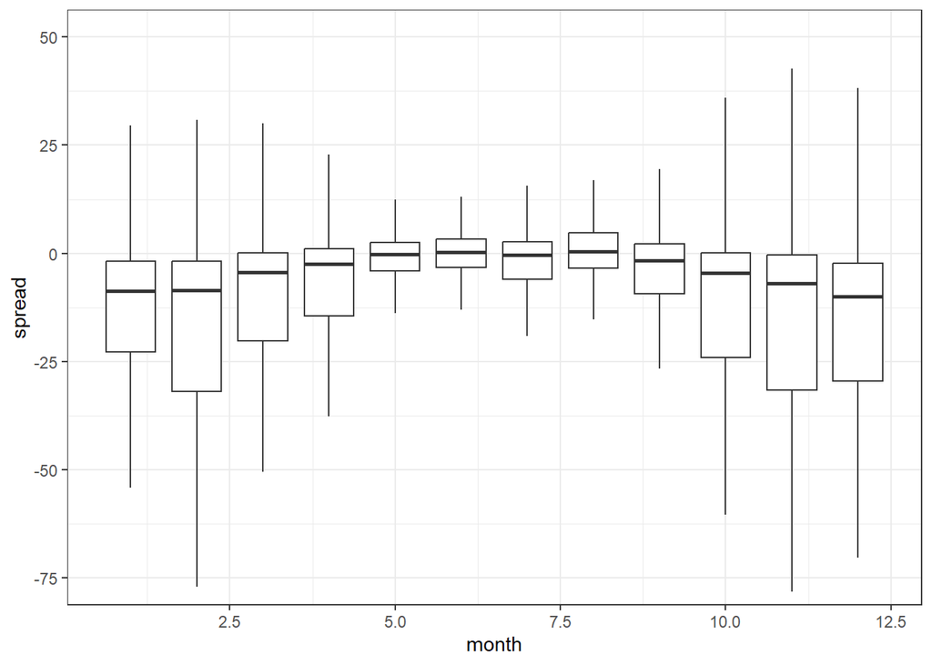

```r
df |>
  transmute(date, auction_price_ch_de,
            spread = day_ahead_price_de - day_ahead_price_ch) |>
  mutate(month = month(date)) |>
  ggplot(aes(month, spread, group = month)) +
  geom_boxplot(outlier.colour = NA) +
  coord_cartesian(ylim = c(-75, 50))
```

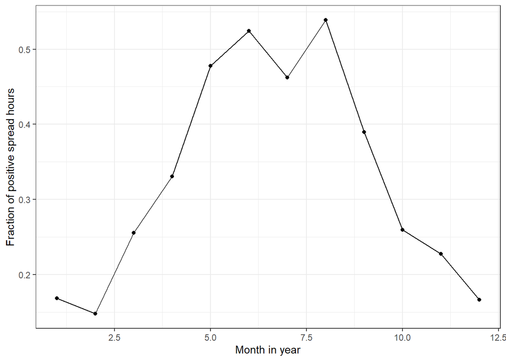

```r
df |>
  transmute(date, auction_price_ch_de,
            spread = day_ahead_price_de - day_ahead_price_ch) |>
  mutate(month = month(date)) |>
  group_by(month) |>
  summarise(positive = mean(spread > 0)) |>
  ggplot(aes(month, positive)) +
  geom_line() +
  geom_point() +
  labs(y = "Fraction of positive spread hours", x = "Month in year")
```

Similar picture for week in year:

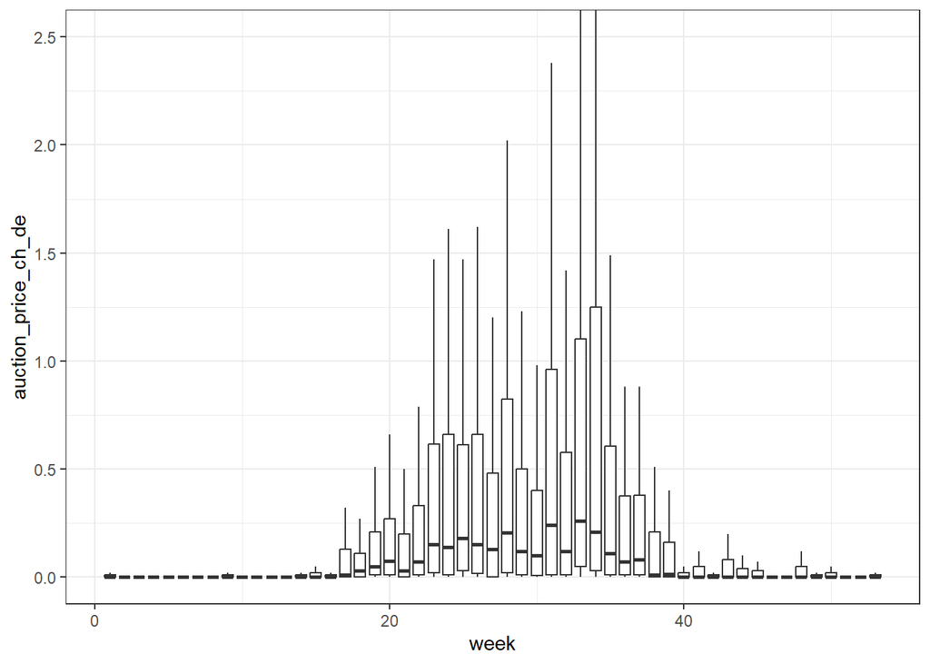

```r
df |>
  mutate(week = week(date)) |>
  ggplot(aes(week, auction_price_ch_de, group = week)) +
  geom_boxplot(outlier.colour = NA) +
  coord_cartesian(ylim = c(0, 2.5))
```

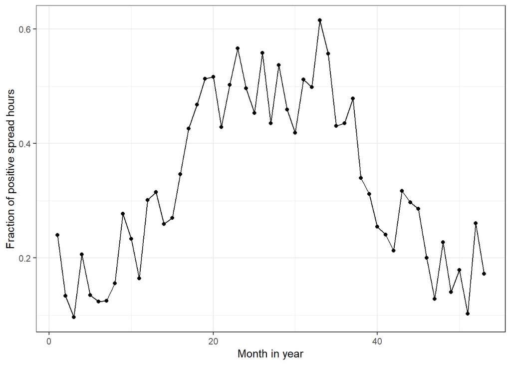

```r
df |>
  transmute(date, auction_price_ch_de,
            spread = day_ahead_price_de - day_ahead_price_ch) |>
  mutate(week = week(date)) |>
  group_by(week) |>
  summarise(positive = mean(spread > 0)) |>
  ggplot(aes(week, positive)) +
  geom_line() +
  geom_point() +
  labs(y = "Fraction of positive spread hours", x = "Month in year")
```

Slight structure in weekday which is not really backed up by the spread.

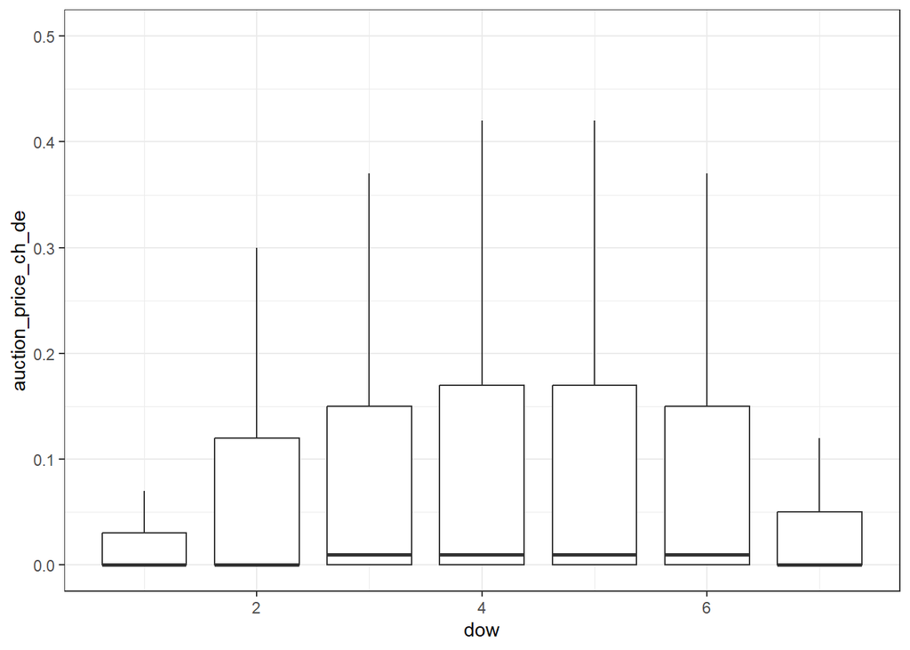

```r
df |>
  mutate(dow = wday(date)) |>
  ggplot(aes(dow, auction_price_ch_de, group = dow)) +
  geom_boxplot(outlier.colour = NA) +
  coord_cartesian(ylim = c(0, 0.5))
```

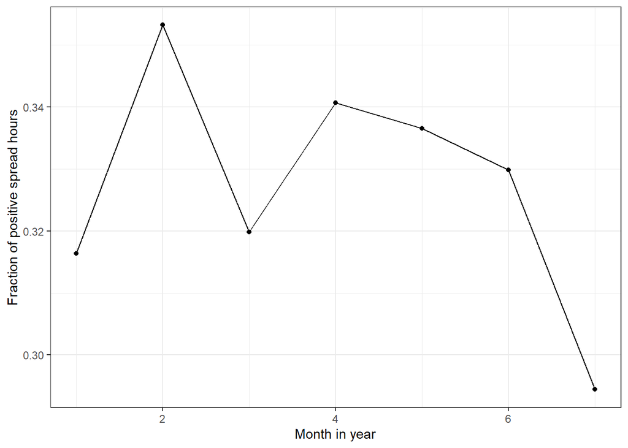

```r
df |>
  transmute(date, auction_price_ch_de,
            spread = day_ahead_price_de - day_ahead_price_ch) |>
  mutate(dow = wday(date)) |>
  group_by(dow) |>
  summarise(positive = mean(spread > 0)) |>
  ggplot(aes(dow, positive)) +
  geom_line() +
  geom_point() +
  labs(y = "Fraction of positive spread hours", x = "Month in year")
```

There is a VERY strong structure in the hour in day.

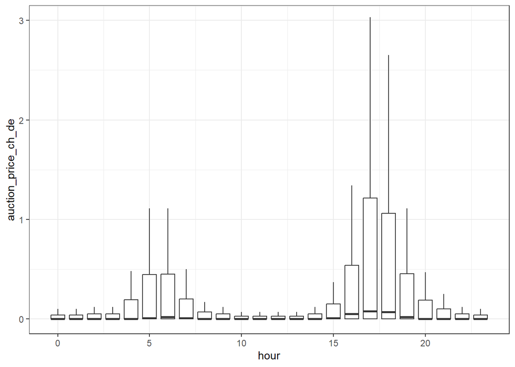

```r
df |>
  mutate(hour = hour(date)) |>
  ggplot(aes(hour, auction_price_ch_de, group = hour)) +
  geom_boxplot(outlier.colour = NA) +
  coord_cartesian(ylim = c(0, 3))
```

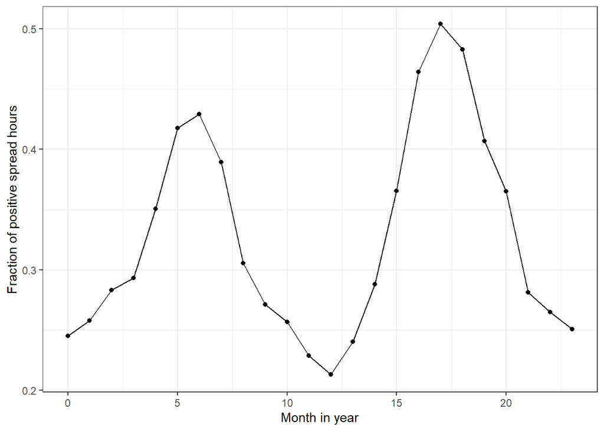

```r
df |>
  transmute(date, auction_price_ch_de,
            spread = day_ahead_price_de - day_ahead_price_ch) |>
  mutate(hour = hour(date)) |>
  group_by(hour) |>
  summarise(positive = mean(spread > 0)) |>
  ggplot(aes(hour, positive)) +
  geom_line() +
  geom_point() +
  labs(y = "Fraction of positive spread hours", x = "Month in year")
```

Dig into this by quarter: Weirdly, the spread exhibits a similar structure but the JAO pricing does not. Analyse the mispricing below.

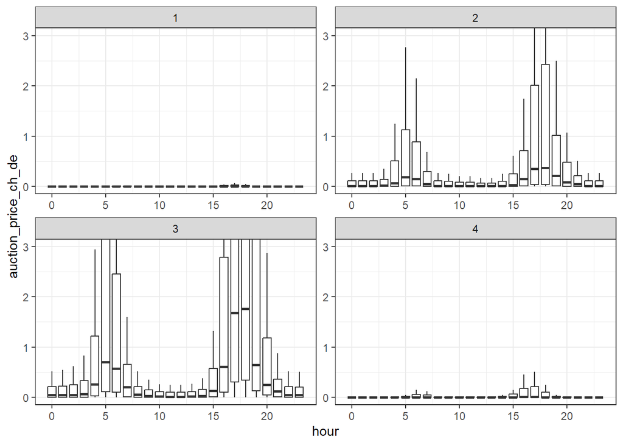

```r
df |>
  mutate(hour = hour(date), quarter = quarter(date)) |>
  ggplot(aes(hour, auction_price_ch_de, group = hour)) +
  geom_boxplot(outlier.colour = NA) +
  coord_cartesian(ylim = c(0, 3)) +
  facet_wrap(~ quarter, scales = "free")
```

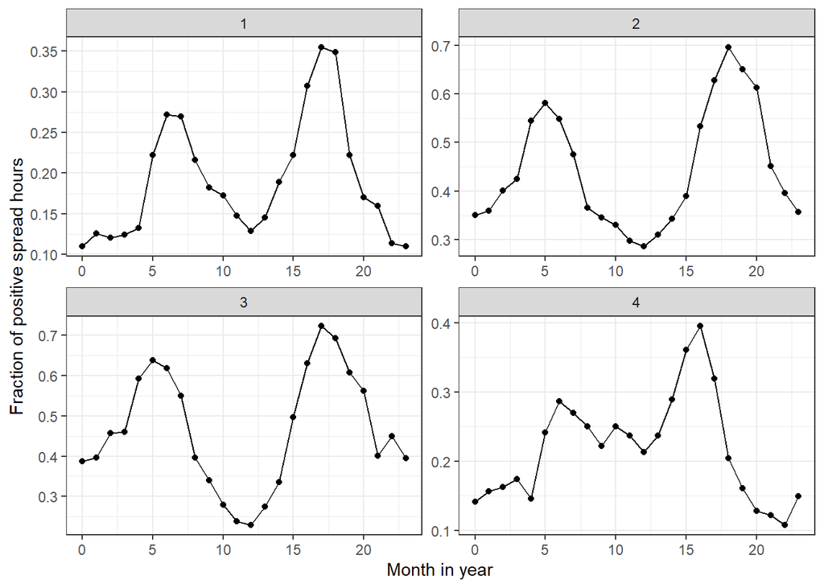

```r
df |>
  transmute(date, auction_price_ch_de,
            spread = day_ahead_price_de - day_ahead_price_ch) |>
  mutate(hour = hour(date), quarter = quarter(date)) |>
  group_by(hour, quarter) |>
  summarise(positive = mean(spread > 0)) |>
  ungroup() |>
  ggplot(aes(hour, positive)) +
  geom_line() +
  geom_point() +
  labs(y = "Fraction of positive spread hours", x = "Month in year") +
  facet_wrap(~ quarter, scales = "free")
```

### Over vs. underpaying

Definitions: - Overpaying: JAO Price > Spread - Underpaying: JAO Price < Spread

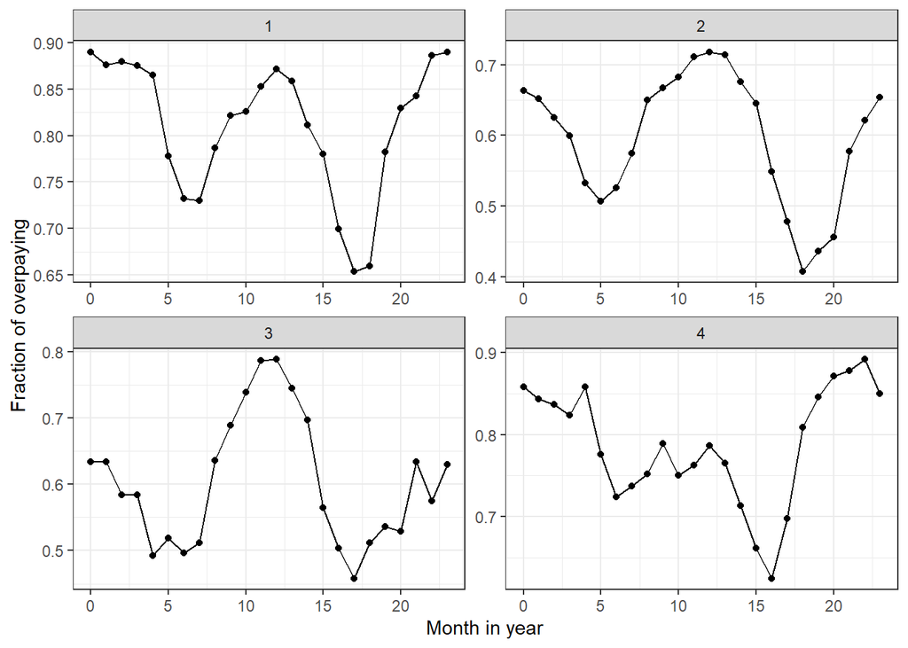

```r
df |>
  transmute(date, auction_price_ch_de,
            spread = day_ahead_price_de - day_ahead_price_ch) |>
  # filter(spread > 0) |>
  mutate(hour = hour(date), quarter = quarter(date)) |>
  group_by(hour, quarter) |>
  summarise(overpaid = mean(auction_price_ch_de > spread)) |>
  ungroup() |>
  ggplot(aes(hour, overpaid)) +
  geom_line() +
  geom_point() +
  labs(y = "Fraction of overpaying", x = "Month in year") +
  facet_wrap(~ quarter, scales = "free")
```

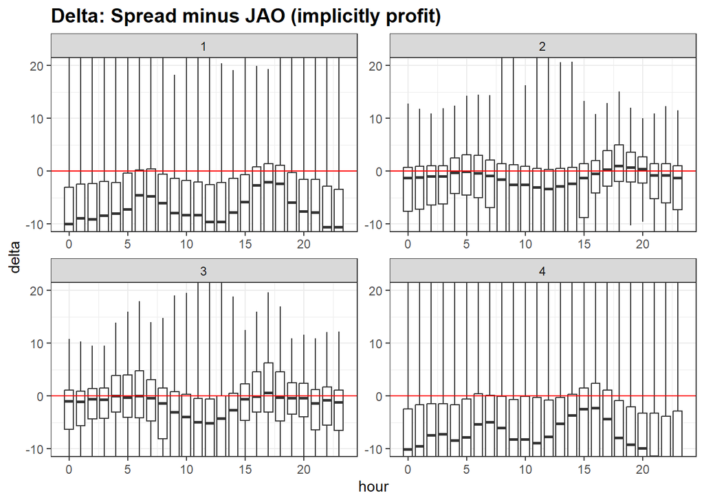

```r
df |>
  transmute(date, auction_price_ch_de,
            spread = day_ahead_price_de - day_ahead_price_ch) |>
  # filter(spread > 0) |>
  mutate(delta = spread - auction_price_ch_de) |>
  mutate(hour = hour(date), quarter = quarter(date)) |>
  ggplot(aes(hour, delta, group = hour)) +
  geom_boxplot(outlier.colour = NA) +
  facet_wrap(~ quarter, scales = "free") +
  coord_cartesian(ylim = c(-10, 20)) +
  geom_hline(yintercept = 0, colour = "red") +
  labs(title = "Delta: Spread minus JAO (implicitly profit)")
```

JAO is a lot more competitive in the summer as the spread if more positive in these situations.

### Seasonality of spread

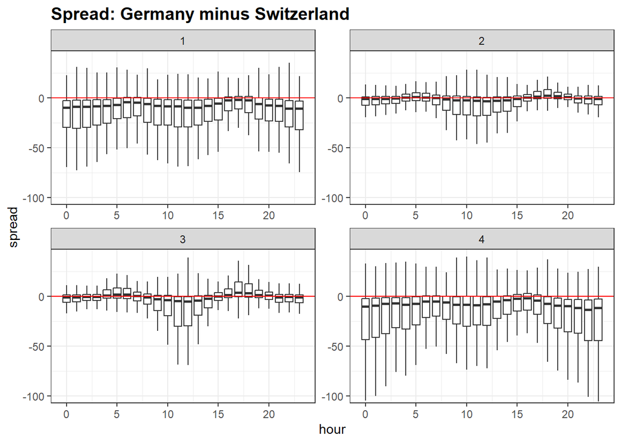

```r
df |>
  transmute(date, auction_price_ch_de,
            spread = day_ahead_price_de - day_ahead_price_ch) |>
  mutate(hour = hour(date), quarter = quarter(date)) |>
  ggplot(aes(hour, spread, group = hour)) +
  geom_boxplot(outlier.colour = NA) +
  facet_wrap(~ quarter, scales = "free") +
  coord_cartesian(ylim = c(-100, 40)) +
  geom_hline(yintercept = 0, colour = "red") +
  labs(title = "Spread: Germany minus Switzerland")
```

The spread follows the duck curve in the Summer.

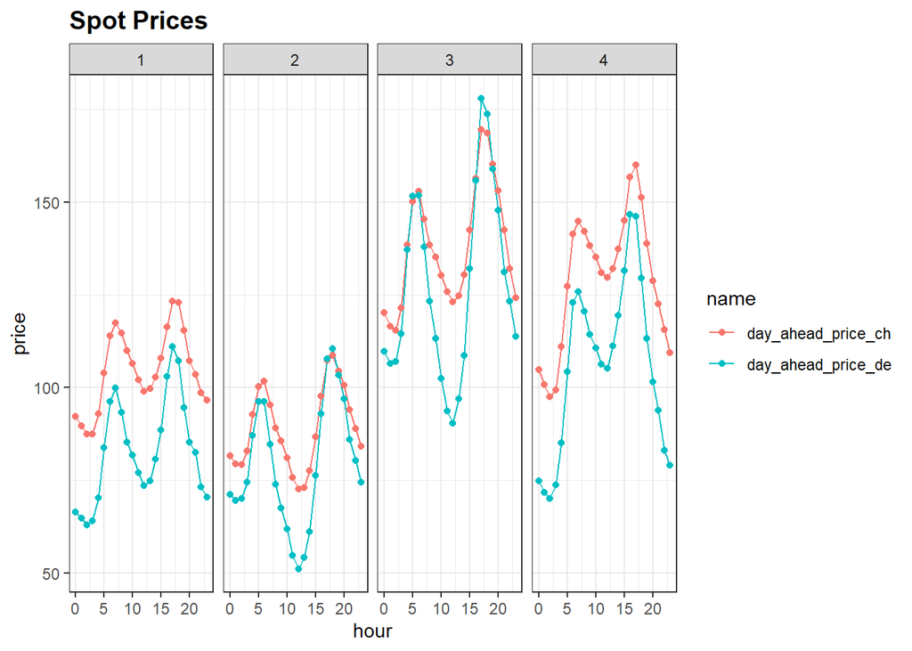

```r
df |>
  transmute(date, day_ahead_price_de, day_ahead_price_ch) |>
  mutate(hour = hour(date), quarter = quarter(date)) |>
  pivot_longer(-c(date, quarter, hour)) |>
  group_by(hour, quarter, name) |>
  summarise(price = mean(value)) |>
  ggplot(aes(hour, price, colour = name)) +
  geom_line() +
  geom_point() +
  facet_wrap(~ quarter, nrow = 1) +
  labs(title = "Spot Prices")
```

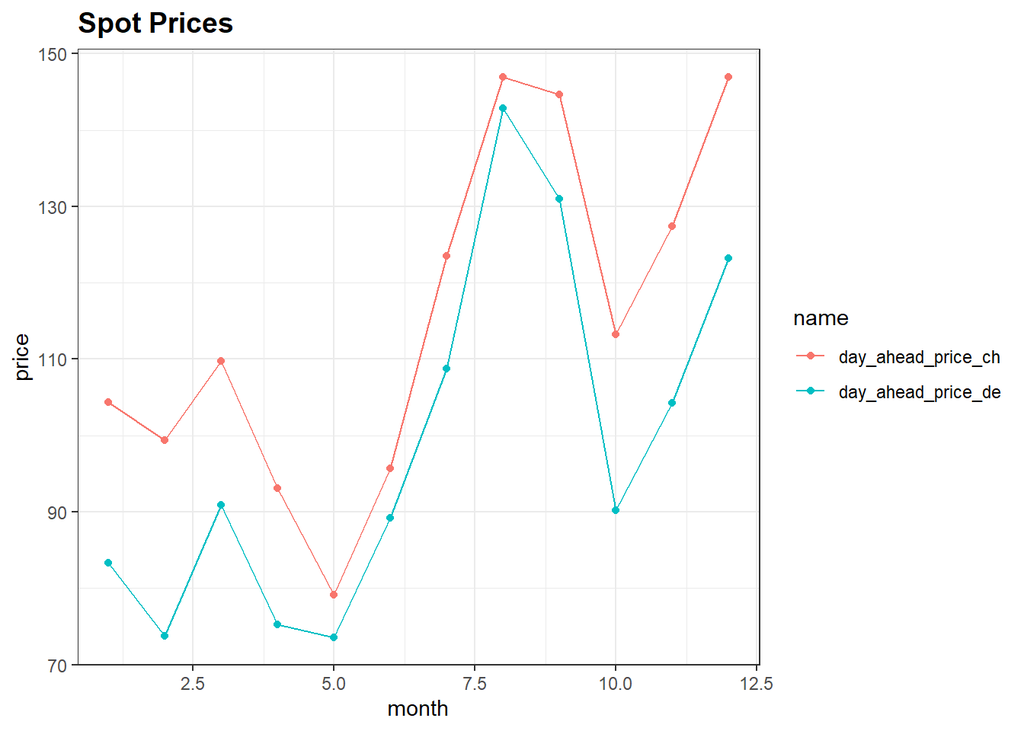

```r
df |>
  transmute(date, day_ahead_price_de, day_ahead_price_ch) |>
  mutate(month = month(date)) |>
  pivot_longer(-c(date, month)) |>
  group_by(month, name) |>
  summarise(price = mean(value)) |>
  ggplot(aes(month, price, colour = name)) +
  geom_line() +
  geom_point() +
  labs(title = "Spot Prices")
```

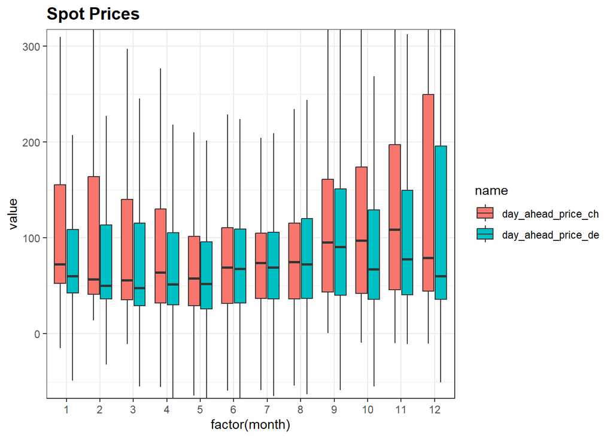

```r
df |>
  transmute(date, day_ahead_price_de, day_ahead_price_ch) |>
  mutate(month = month(date)) |>
  pivot_longer(-c(date, month)) |>
  ggplot(aes(factor(month), value, fill = name)) +
  geom_boxplot(outlier.colour = NA) +
  coord_cartesian(ylim = c(-50, 300)) +
  labs(title = "Spot Prices")
```

### Correlation Plot

[figure not shown]

```r
corrplot::corrplot(
  cor(
    df |>
      select(where(is.numeric))
  ),
  method = "color", diag = T, type = "upper",
  tl.cex = 0.75, tl.col = "black"
)
```

### Variable selection with LASSO

```r
fit_lasso <- function(lambda, tbl){
  lasso_fit <- workflow() %>%
    add_model(linear_reg(mixture = 1, penalty = lambda) %>%
                set_mode("regression") %>%
                set_engine("glmnet")) %>%
    add_recipe(
      recipe(auction_price_ch_de ~ ., data = tbl) |>
        step_mutate(hour = hour(date)) |>
        step_date(date) |>
        update_role(date, new_role = "date") |>
        step_zv(all_predictors()) |>
        step_center(all_numeric_predictors()) |>
        step_scale(all_numeric_predictors()) |>
        step_dummy(all_nominal_predictors())
    ) %>%
    fit(tbl) %>%
    tidy() %>%
    filter(term != "(Intercept)",
           estimate != 0)

  return(lasso_fit)

}

fit_lasso(0.01, df) %>%
  head()
```

```
## # A tibble: 6 × 3
##   term                    estimate penalty
##   <chr>                      <dbl>   <dbl>
## 1 allocatedCapacity_ch_de  -1.58      0.01
## 2 day_ahead_price_at        0.772     0.01
## 3 day_ahead_price_ch       -0.641     0.01
## 4 day_ahead_price_de        0.191     0.01
## 5 day_ahead_price_fr       -0.317     0.01
## 6 actual_load_at            0.0345    0.01
```

```r
lambda_fits <- tibble(
  lambdas = seq(0, 2, length.out = 25),
  coefs = map(lambdas, ~ fit_lasso(.x, df)),
  n_coefs = map(coefs, ~ nrow(.x))
) %>%
  unnest(n_coefs)

lambda_fits
```

```
## # A tibble: 25 × 3
##    lambdas coefs              n_coefs
##      <dbl> <list>               <int>
##  1  0      <tibble [106 × 3]>     106
##  2  0.0833 <tibble [22 × 3]>       22
##  3  0.167  <tibble [8 × 3]>         8
##  4  0.25   <tibble [6 × 3]>         6
##  5  0.333  <tibble [5 × 3]>         5
##  6  0.417  <tibble [4 × 3]>         4
##  7  0.5    <tibble [3 × 3]>         3
##  8  0.583  <tibble [3 × 3]>         3
##  9  0.667  <tibble [1 × 3]>         1
## 10  0.75   <tibble [1 × 3]>         1
## # ℹ 15 more rows
```

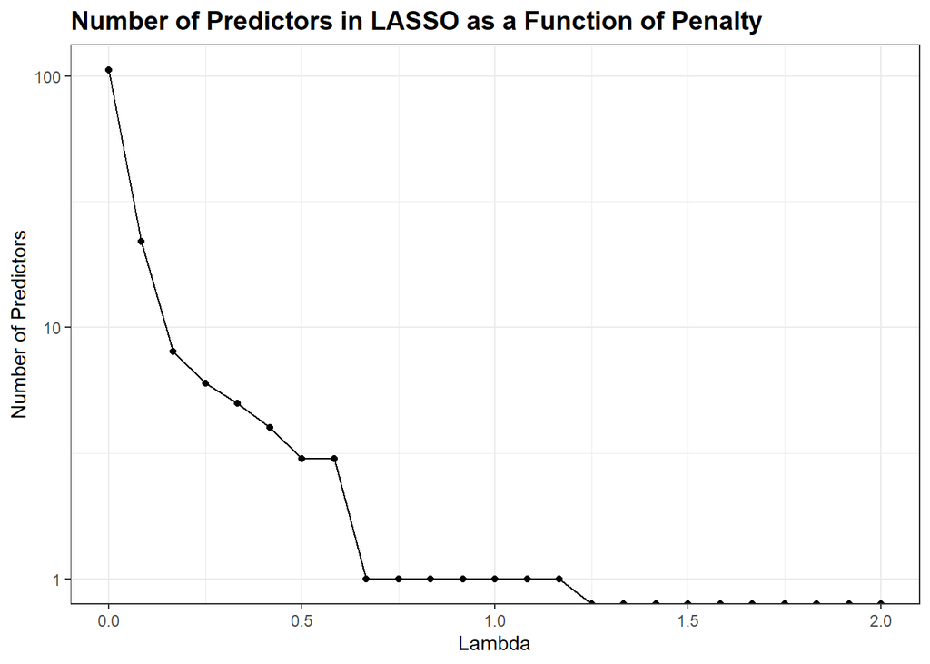

```r
lambda_fits %>%
  ggplot(aes(lambdas, n_coefs)) +
  geom_point() +
  geom_line() +
  labs(title = "Number of Predictors in LASSO as a Function of Penalty",
       y = "Number of Predictors",
       x = "Lambda") +
  scale_y_log10(labels = comma_format(), breaks = 10^(0:3),
                limits = c(1, NA)) +
  scale_x_continuous(labels = comma_format())
```

#### Tuning and training the lasso model

```r
start_date = min(df$date)
split_date = ymd_hm("2020-01-01 00:00")
end_date = ymd_hm("2021-01-01 00:00")

dt_train = df |>
  filter(date > start_date) |>
  filter(date < split_date) |>
  filter(date < end_date)

dt_test = df |>
  filter(date > start_date) |>
  filter(date >= split_date) |>
  filter(date < end_date)
```

```r
# Create recipe
lasso_rec = recipe(auction_price_ch_de ~ ., data = dt_train) |>
  step_mutate(hour = hour(date)) |>
  step_date(date) |>
  update_role(date, new_role = "date") |>
  step_zv(all_predictors()) |>
  step_center(all_numeric_predictors()) |>
  step_scale(all_numeric_predictors()) |>
  step_dummy(all_nominal_predictors())

lasso_rec |> prep() |> juice()
```

```
## # A tibble: 8,758 × 107
##    date                allocatedCapacity_ch_de day_ahead_price_at
##    <dttm>                                <dbl>              <dbl>
##  1 2019-01-01 00:00:00                   0.828            -0.0229
##  2 2019-01-01 01:00:00                   0.828            -0.0214
##  3 2019-01-01 02:00:00                   0.828            -0.931
##  4 2019-01-01 03:00:00                   0.828            -3.09
##  5 2019-01-01 04:00:00                   0.828            -3.40
##  6 2019-01-01 05:00:00                   0.828            -3.75
##  7 2019-01-01 06:00:00                   0.828            -3.52
##  8 2019-01-01 07:00:00                   0.828            -2.94
##  9 2019-01-01 08:00:00                   0.828            -3.03
## 10 2019-01-01 09:00:00                   0.828            -1.96
## # ℹ 8,748 more rows
## # ℹ 104 more variables: day_ahead_price_ch <dbl>, day_ahead_price_de <dbl>,
## #   day_ahead_price_fr <dbl>, actual_load_at <dbl>, actual_load_ch <dbl>,
## #   actual_load_de <dbl>, actual_load_fr <dbl>, actual_load_it <dbl>,
## #   solar_forecast_de <dbl>, wind_onshore_forecast_fr <dbl>,
## #   biomass_actual_aggregated_at <dbl>, fossil_gas_actual_aggregated_at <dbl>,
## #   fossil_hard_coal_actual_aggregated_at <dbl>, …
```

```r
summary(lasso_rec) |> as.data.frame()
```

```
##                                                variable            type
## 1                                                  date        datetime
## 2                               allocatedCapacity_ch_de double, numeric
## 3                                    day_ahead_price_at double, numeric
## 4                                    day_ahead_price_ch double, numeric
## 5                                    day_ahead_price_de double, numeric
## 6                                    day_ahead_price_fr double, numeric
## 7                                        actual_load_at double, numeric
## 8                                        actual_load_ch double, numeric
## 9                                        actual_load_de double, numeric
## 10                                       actual_load_fr double, numeric
## 11                                       actual_load_it double, numeric
## 12                                    solar_forecast_de double, numeric
## 13                             wind_onshore_forecast_fr double, numeric
## 14                         biomass_actual_aggregated_at double, numeric
```

[output cut: 165 more lines]

```r
# Setting up the tuning grid
lasso_grid <- seq(0.00001, 0.1, length.out = 25)

# Tune the parameter
train_metrics = c()
test_metrics = c()

fit_lasso = function(alpha){
  # Setting up specifications
  lasso_spec = linear_reg(mixture = 1, penalty = alpha) %>%
    set_mode("regression") %>%
    set_engine("glmnet")

  # Setting up workflow
  lasso_wflow = workflow() |>
    add_model(lasso_spec) |>
    add_recipe(lasso_rec)

  # Fit the model with parameter
  lasso_fit = lasso_wflow |>
    fit(dt_train)
}

for (i in 1:length(lasso_grid)){

  # Fit lasso with parameter
  lasso_fit = fit_lasso(alpha = lasso_grid[i])

  # Make predictions and store the metric
  train_metrics = append(
    train_metrics,
    lasso_fit |>
      predict(dt_train) |>
      mutate(actual = dt_train$auction_price_ch_de) |>
      rmse(actual, .pred) |>
      pull(.estimate)
  )

  test_metrics = append(
    test_metrics,
    lasso_fit |>
      predict(dt_test) |>
      mutate(actual = dt_test$auction_price_ch_de) |>
      rmse(actual, .pred) |>
      pull(.estimate)
  )

  print(paste(i, "done out of", length(lasso_grid)))
}
```

```
## [1] "1 done out of 25"
## [1] "2 done out of 25"
## [1] "3 done out of 25"
## [1] "4 done out of 25"
## [1] "5 done out of 25"
## [1] "6 done out of 25"
## [1] "7 done out of 25"
## [1] "8 done out of 25"
## [1] "9 done out of 25"
## [1] "10 done out of 25"
## [1] "11 done out of 25"
## [1] "12 done out of 25"
## [1] "13 done out of 25"
## [1] "14 done out of 25"
## [1] "15 done out of 25"
## [1] "16 done out of 25"
## [1] "17 done out of 25"
## [1] "18 done out of 25"
## [1] "19 done out of 25"
## [1] "20 done out of 25"
## [1] "21 done out of 25"
## [1] "22 done out of 25"
## [1] "23 done out of 25"
## [1] "24 done out of 25"
## [1] "25 done out of 25"
```

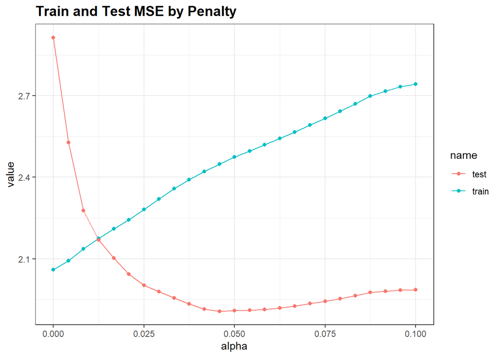

```r
tuning_results = tibble(
  alpha = lasso_grid,
  train = train_metrics,
  test = test_metrics
)

tuning_results |>
  pivot_longer(-alpha) |>
  mutate(value = value^2) |>
  ggplot(aes(alpha, value, colour = name)) +
  geom_line() +
  geom_point() +
  labs(title = "Train and Test MSE by Penalty")
```

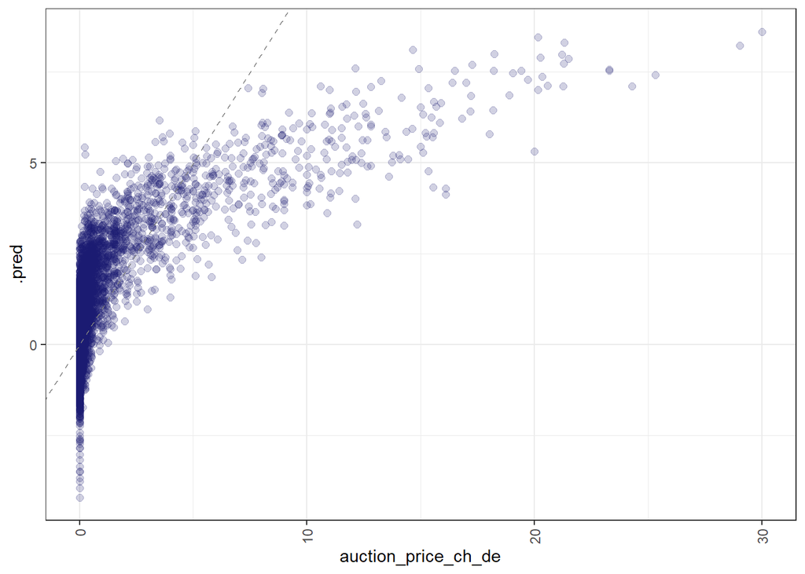

```r
# Fitting the model
lasso_fit = fit_lasso(alpha = 0.0125)

# Predictions vs actuals in-sample
lasso_fit |>
  augment(dt_train) |>
  ggplot(aes(auction_price_ch_de, .pred)) +
  geom_point(alpha = 0.2, colour = "midnightblue", size = 2) +
  geom_abline(lty = "dashed", colour = "grey50") +
  scale_x_continuous(labels = scales::comma_format()) +
  scale_y_continuous(labels = scales::comma_format()) +
  theme_bw() +
  theme(axis.text.x = element_text(angle = 90, hjust = 1, vjust = 0.5))
```

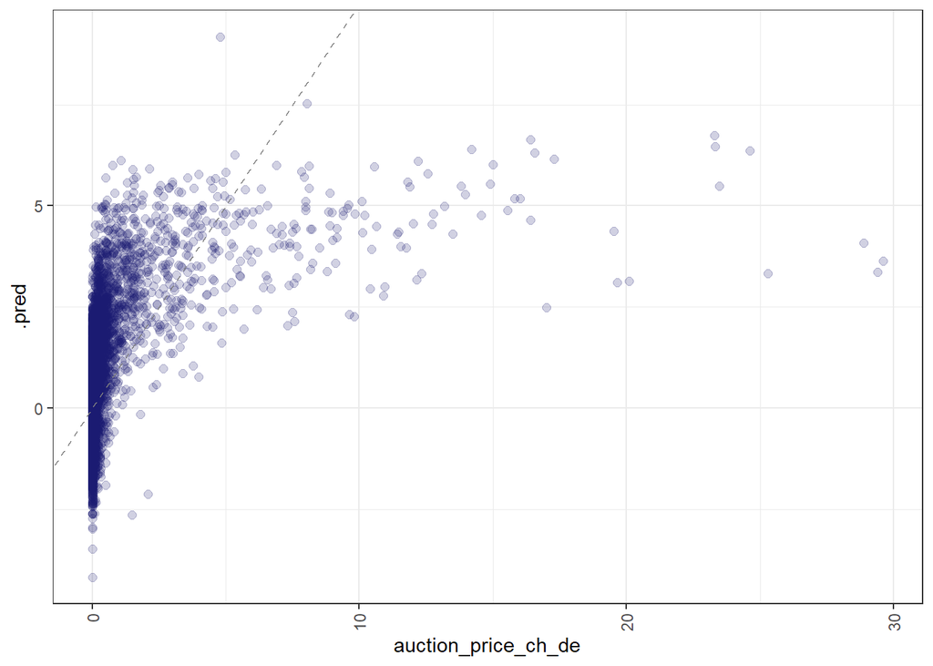

```r
# Predictions vs actuals out-of-sample
lasso_fit |>
  augment(dt_test) |>
  ggplot(aes(auction_price_ch_de, .pred)) +
  geom_point(alpha = 0.2, colour = "midnightblue", size = 2) +
  geom_abline(lty = "dashed", colour = "grey50") +
  scale_x_continuous(labels = scales::comma_format()) +
  scale_y_continuous(labels = scales::comma_format()) +
  theme_bw() +
  theme(axis.text.x = element_text(angle = 90, hjust = 1, vjust = 0.5))
```

```r
# Get the variables that remained in the model
lasso_fit |>
  tidy() |>
  filter(estimate > 0,
         ! str_detect(term, "Intercept")) |>
  pull(term)
```

```
##  [1] "day_ahead_price_at"
##  [2] "day_ahead_price_de"
##  [3] "actual_load_de"
##  [4] "wind_onshore_forecast_fr"
##  [5] "fossil_gas_actual_aggregated_at"
##  [6] "hydro_pumped_storage_actual_consumption_at"
##  [7] "hydro_run-of-river_and_poundage_actual_aggregated_at"
##  [8] "hydro_water_reservoir_actual_aggregated_at"
##  [9] "wind_onshore_actual_aggregated_at"
## [10] "wind_onshore_ch"
## [11] "biomass_actual_aggregated_de"
## [12] "fossil_gas_actual_aggregated_de"
## [13] "hydro_pumped_storage_actual_aggregated_de"
## [14] "hydro_water_reservoir_actual_aggregated_de"
## [15] "waste_actual_aggregated_de"
```

[output cut: 26 more lines]

### Variable Importance with Random Forest

Should give a general impression of which variables might be important

```r
# Create recipe
rf_rec = recipe(auction_price_ch_de ~ ., data = dt_train) |>
  step_mutate(hour = hour(date)) |>
  step_date(date) |>
  update_role(date, new_role = "date") |>
  step_zv(all_predictors()) |>
  step_center(all_numeric_predictors()) |>
  step_scale(all_numeric_predictors())

rf_rec |> prep() |> juice()
```

```
## # A tibble: 8,758 × 92
##    date                allocatedCapacity_ch_de day_ahead_price_at
##    <dttm>                                <dbl>              <dbl>
##  1 2019-01-01 00:00:00                   0.828            -0.0229
##  2 2019-01-01 01:00:00                   0.828            -0.0214
##  3 2019-01-01 02:00:00                   0.828            -0.931
##  4 2019-01-01 03:00:00                   0.828            -3.09
##  5 2019-01-01 04:00:00                   0.828            -3.40
##  6 2019-01-01 05:00:00                   0.828            -3.75
##  7 2019-01-01 06:00:00                   0.828            -3.52
##  8 2019-01-01 07:00:00                   0.828            -2.94
##  9 2019-01-01 08:00:00                   0.828            -3.03
## 10 2019-01-01 09:00:00                   0.828            -1.96
## # ℹ 8,748 more rows
## # ℹ 89 more variables: day_ahead_price_ch <dbl>, day_ahead_price_de <dbl>,
## #   day_ahead_price_fr <dbl>, actual_load_at <dbl>, actual_load_ch <dbl>,
## #   actual_load_de <dbl>, actual_load_fr <dbl>, actual_load_it <dbl>,
## #   solar_forecast_de <dbl>, wind_onshore_forecast_fr <dbl>,
## #   biomass_actual_aggregated_at <dbl>, fossil_gas_actual_aggregated_at <dbl>,
## #   fossil_hard_coal_actual_aggregated_at <dbl>, …
```

```r
summary(rf_rec) |> as.data.frame()
```

```
##                                                variable            type
## 1                                                  date        datetime
## 2                               allocatedCapacity_ch_de double, numeric
## 3                                    day_ahead_price_at double, numeric
## 4                                    day_ahead_price_ch double, numeric
## 5                                    day_ahead_price_de double, numeric
## 6                                    day_ahead_price_fr double, numeric
## 7                                        actual_load_at double, numeric
## 8                                        actual_load_ch double, numeric
## 9                                        actual_load_de double, numeric
## 10                                       actual_load_fr double, numeric
## 11                                       actual_load_it double, numeric
## 12                                    solar_forecast_de double, numeric
## 13                             wind_onshore_forecast_fr double, numeric
## 14                         biomass_actual_aggregated_at double, numeric
```

[output cut: 165 more lines]

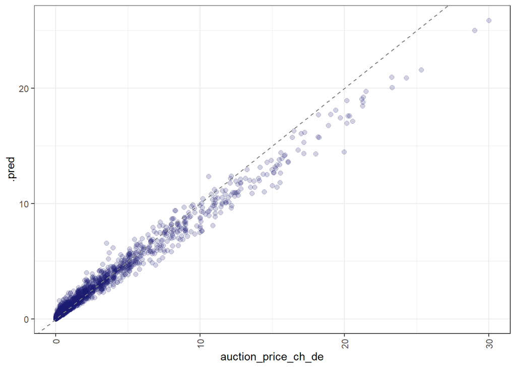

```r
# Setting up specifications
rf_spec = rand_forest() |>
  set_engine("ranger", importance = "impurity") |>
  set_mode("regression")

# Setting up workflow
rf_wflow = workflow() |>
  add_model(rf_spec) |>
  add_recipe(rf_rec)

# Fitting the model
rf_fit = rf_wflow |>
  fit(dt_train)

# Predictions vs actuals in-sample
rf_fit |>
  augment(dt_train) |>
  ggplot(aes(auction_price_ch_de, .pred)) +
  geom_point(alpha = 0.2, colour = "midnightblue", size = 2) +
  geom_abline(lty = "dashed", colour = "grey50") +
  scale_x_continuous(labels = scales::comma_format()) +
  scale_y_continuous(labels = scales::comma_format()) +
  theme_bw() +
  theme(axis.text.x = element_text(angle = 90, hjust = 1, vjust = 0.5))
```

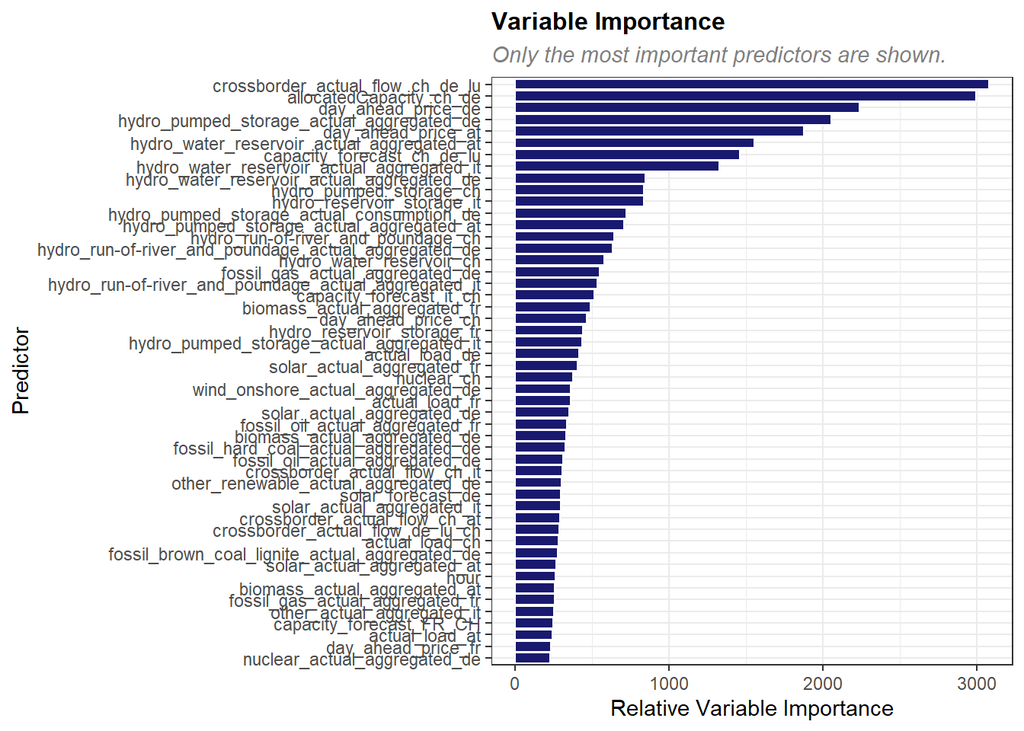

```r
# Get feature importance
rf_fit |>
  extract_fit_parsnip() |>
  vip::vi() |>
  as_tibble() |>
  slice_max(order_by = Importance, n = 50) %>%
  ggplot(aes(Importance, reorder(Variable, Importance))) +
  geom_col(fill = "midnightblue", colour = "white") +
  labs(title = "Variable Importance",
       subtitle = "Only the most important predictors are shown.",
       y = "Predictor",
       x = "Relative Variable Importance") +
  theme_bw() +
  theme(plot.title = element_text(face = "bold", size = 12),
        plot.subtitle = element_text(face = "italic", colour = "grey50"))
```